# Why Rock Dies In 2010s?

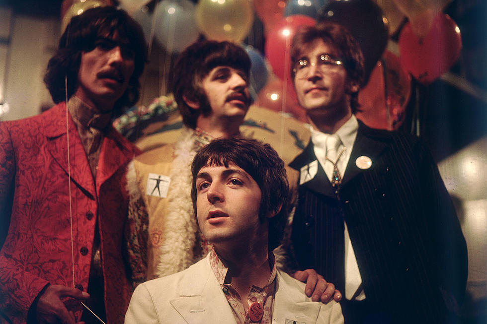

As millenials, although we certainly did not experience the heat brought by “The Beatles” and “Elvis Presley”, these names are far more than familiar to us. However as we entered 2010s, rock music seems to become less and less prevalant in our life. How did this happened and why? Let’s figure it out.

```r
# loading required packages
library(tidyverse)
library(tidytext)
library(tm)
library(DT)
library(scales)
library(wordcloud)
library(plotrix)
library(beeswarm)
library(GGally)
library(plotly)
library(shiny)
library(textdata)
```

```r
# loading data
load('../output/processed_lyrics.RData')
```

# Outdated Social Values of Metal Music

As a sub-division of Rock music, Metal music was originated in 1970s largely due to the consistent tension from cold war. People are looking for more extreme ways to fight against pressure from uniformness(Dunn, n.d.).

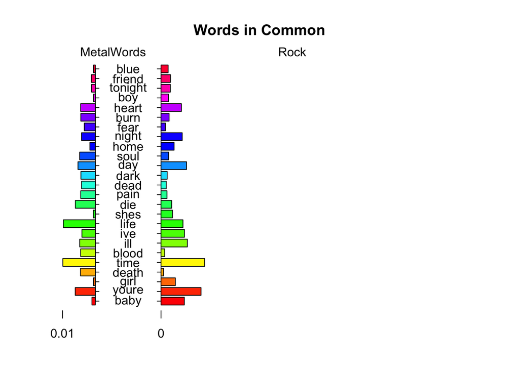

```
## [1] 5.1 4.1 4.1 2.1
```

```r
# create a corpus with all metal and rock music
all_metal <- dt_lyrics %>% filter(genre=="Metal") %>%
  select(stemmedwords) %>%
  paste(., collapse = "")

all_rock <- dt_lyrics %>% filter(genre=="Rock") %>%
  select(stemmedwords) %>%
  paste(., collapse = "")

all_metal_rock <- c(all_metal, all_rock)

metal_rock_corpus <- VCorpus(VectorSource(all_metal_rock))
metal_rock_tdm <-as.matrix(TermDocumentMatrix(metal_rock_corpus))
colnames(metal_rock_tdm) <- c('Metal',"Rock")

# create a dataframe with all metal and rock music
metal_rock_df <- data.frame(metal_rock_tdm) %>%
  rownames_to_column(var="words")

# find out the total number words in rock and metal respectivly
#sum(metal_rock_df$Metal) # 822771
#sum(metal_rock_df$Rock) # 4019428

# find out the common words in metal and rock
common_words_prc <- metal_rock_df %>%
  filter(Metal !=0 & Rock !=0) %>%
  mutate(Metal_prc = Metal/822771,
         Rock_prc = Rock / 4019428) %>%
  mutate(diff = abs(Metal_prc-Rock_prc)) %>%
  arrange(desc(diff))

# select top 25 words
top_25_prc <- top_n(common_words_prc, 25, diff)
pyramid.plot(top_25_prc$Metal_prc, top_25_prc$Rock_prc,
             labels = top_25_prc$words,
             main="Words in Common",
             gap=0.01,
             laxlab = NULL,
             raxlab = NULL,
             unit = NULL,
             xlim = c(0.02,0.1),
             top.labels = c("Metal","Words","Rock"))
```

After examine the relative frequency of each word in both Metal and Rock music, we see that, although originated from Rock music, there are a lot more heavy and extreme topics, such as “death” and “die” in Metal music.

Moreover, we see that word “shes” and “girl” appear far less frequent in Metal music than Rock. This is because Metal music is male dominant and express misogynist(Cope 2010). However, along with the social movements, such as **Feminism** and **Civil Rights Movements**, female and black artist started entering the stage. And people were largly criticizing the misogynism expressed in Metal music, which creates bad influence to Rock music in later decades.

# Technology Changes The Music Industry

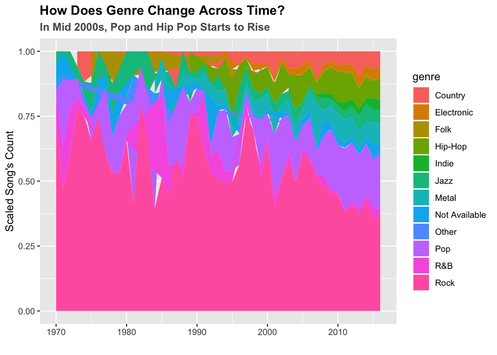

```r
dt_lyrics <- dt_lyrics %>%
  mutate(decades = case_when(year >= 1970 & year < 1980 ~ "1970s",
                             year >= 1980 & year < 1990 ~ "1980s",
                             year >= 1990 & year < 2000 ~ "1990s",
                             year >= 2000 & year < 2010 ~ "2000s",
                             year >= 2010 & year < 2020 ~ "2010s"))

song_num_cross_time <- dt_lyrics %>%
  count(genre, year) %>%
  filter(year >= 1970) %>%
  group_by(year) %>%
  summarise(n_total=sum(n))

dt_lyrics %>%
  filter(year >= 1970) %>%
  count(genre, year) %>%
  inner_join(song_num_cross_time, by="year") %>%
  mutate(n_prc = n/n_total) %>%
  ggplot(aes(x=year, y=n_prc, fill=genre)) +
  geom_area() +
  xlab("") +
  ylab("Scaled Song's Count") +
  ggtitle("How Does Genre Change Across Time?",
          subtitle = "In Mid 2000s, Pop and Hip Pop Starts to Rise") +
  theme(plot.title = element_text(face = "bold")) +
  theme(plot.subtitle = element_text(face = "bold", color = "grey35")) +
  geom_text(x=3,y=2.7, label="Rock", color="grey35", alpha = 0.2)+
  geom_text(x=3,y=0.5, label="Pop", color="grey35", alpha = 0.2) +
  geom_text(x=5,y=0.3, label=paste("Hip Hop", ""), color="grey35", alpha = 0.2)
```

As technology makes furthur advancements in 2010s, which lowers the bar of being a producer and singer, more people join the army of Pop or Hip Hop instead of Rock music, which requires significant music talent to perfome and produce.

# Prevailing Terrorism

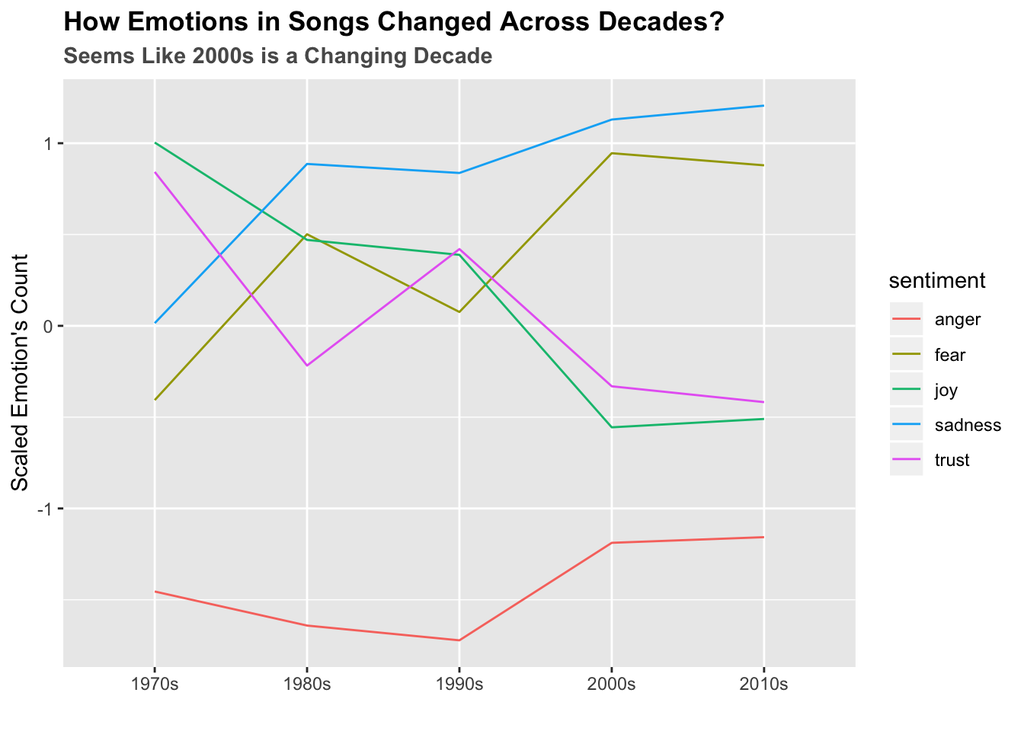

```r
# use NRC Lexicon to perform sentiment analysis
lyric_emotion <- dt_lyrics %>%
  unnest_tokens(word, stemmedwords) %>%
  inner_join(get_sentiments("nrc"), by="word")

lyric_emotion %>%
  count(decades,sentiment) %>%
  drop_na(decades) %>%
  filter(sentiment  %in% c("anger","fear","joy","sadness","trust")) %>%
  group_by(decades) %>%
  mutate(n_prc = n/sum(n)) %>%
  select(-n) %>%
  spread(key=decades, value = n_prc) %>%
  ggparcoord(columns = 2:6, groupColumn = 1) +
  xlab("") +
  ylab("Scaled Emotion's Count") +
  ggtitle("How Emotions in Songs Changed Across Decades?",
          subtitle = "Seems Like 2000s is a Changing Decade") +
  theme(plot.title = element_text(face = "bold")) +
  theme(plot.subtitle = element_text(face = "bold", color = "grey35"))
```

Starting early 2000s, **Terrorism** started to prevail the world, which was reflected in the sentiment analysis above. We see an immediate increase of **anger**, **sadness**, and **fear** in 2000s. At the same time, positive emotions, such as **joy** and **trust** decreased in 2000s.

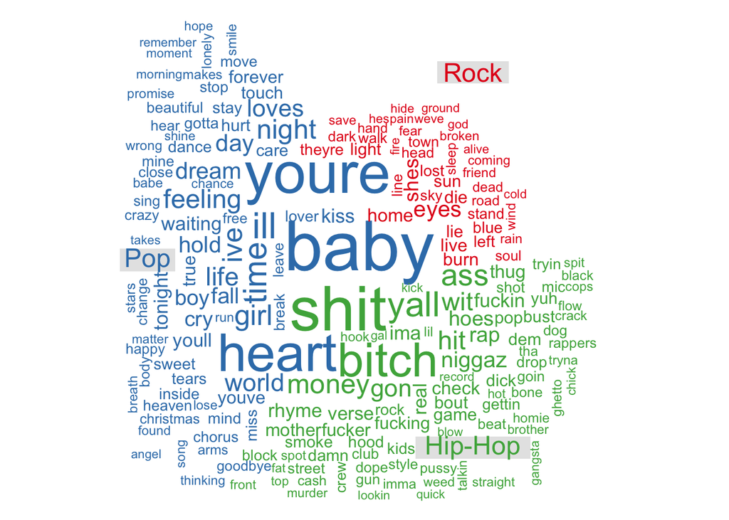

```r
# create a corpus with rock, pop, and hip hop music
all_pop <- dt_lyrics %>% filter(genre=="Pop") %>%
  select(stemmedwords) %>%
  paste(., collapse = "")

all_hiphop <- dt_lyrics %>% filter(genre=="Hip-Hop") %>%
  select(stemmedwords) %>%
  paste(., collapse = "")

all_rock_pop_hiphop <- c(all_rock, all_pop, all_hiphop)

rock_pop_hiphop_corpus <- VCorpus(VectorSource(all_rock_pop_hiphop))
rock_pop_hiphop_corpus <- tm_map(rock_pop_hiphop_corpus, removeWords, c("niggas"))
rock_pop_hiphop_tdm <-as.matrix(TermDocumentMatrix(rock_pop_hiphop_corpus))
colnames(rock_pop_hiphop_tdm) <- c("Rock","Pop", "Hip-Hop")

# comparison cloud
comparison.cloud(rock_pop_hiphop_tdm, max.words = 200, colors = brewer.pal(3, "Set1"),
                 random.order = FALSE,
                 title.size = 1.5,
                 match.colors = TRUE)
```

*Note*: because there is word “love” in every genre, I removed it as stop words in the starter code.

Comparing three music genres, we see that there are a lot of bad languages in Hip Hop songs, which is viewed as a more extraverted way of expression compare to Rock(Blanchard 2015). When facing the Terrorist, people prefer a more direct way to express their anger towards Terrorist. Therefore, Hip Hop gradually takes over large portion of market.

Moroever, as Terrorism is getting more and more serious in 2010s. People are tired of heavy topics of Rock music. Musics like Pop where has a lot of light-hearted topics, such as “baby”, “love”, and etc make people more relax. Therefore, we see a slight bounce back of joy in 2010s due to increasing popularity of Pop music.

# Summary

- As a subdivision of Rock, Metal’s inappropriate cultures, such as misogynist creates bad influence to Rock
- Technology development changes the way music produce in 2010s
- Prevailing Terrorism creates social needs for Pop and Hip Pop music to take place of Rock

# Reference

Blanchard, Becky. 2015. “The Social Significance of Rap & Hip-Hop Culture.” *Ethics of Development in a Global Environment (EDGE):“Poverty & Prejudice: Media and Race”*.

Cope, Andrew L. 2010. *Black Sabbath and the Rise of Heavy Metal Music*. Ashgate Publishing.

Costabile, Christopher. 2018. “The Bands Are All Dead: How Rock Can Still Survive the 2010s.” *Music Festival News*.

Dunn, Sam. n.d. *Metal: A Headbanger’s Journey*.